# Using SparkR and sparklyr with 2013 NYCTaxi Data: Data manipulations, modeling, and evaluation

Algorithms and Data Science, Microsoft Data Group

February 05, 2017

# 1 Introduction

We use SparkR for data manipulations (e.g. data joining) and sparklyr for creating and evaluating models. Where necessary, small amounts of data is brought to the local data frames for plotting and visualization.

# 2 Using sparklyr for creating ML models

sparklyr provides bindings to Spark’s distributed machine learning library. In particular, sparklyr allows you to access the machine learning routines provided by the spark.ml package. Together with sparklyr’s dplyr interface, you can easily create and tune machine learning workflows on Spark, orchestrated entirely within R.

## 2.1 Creating spark context / connections and loading required packages

```r
###########################################
# LOAD LIBRARIES FROM SPECIFIED PATH
###########################################
Sys.setenv(YARN_CONF_DIR="/opt/hadoop/current/etc/hadoop", HADOOP_HOME="/opt/hadoop/current",
           JAVA_HOME = "/usr/lib/jvm/java-1.8.0-openjdk-1.8.0.111-1.b15.el7_2.x86_64",
           SPARK_HOME = "/dsvm/tools/spark/current",
           PATH=paste0(Sys.getenv("PATH"),":/opt/hadoop/current/bin"))

list.files(file.path(Sys.getenv("SPARK_HOME"), "R", "lib"))
```

```
## [1] "SparkR"     "sparkr.zip"
```

```r
.libPaths(c(file.path(Sys.getenv("SPARK_HOME"), "R", "lib"), .libPaths()))

library(rmarkdown)
library(knitr)
library(gridExtra)
library(sparklyr)
library(dplyr)
library(DBI)
library(ggplot2)

###########################################
## CREATE SPARKLYR SPARK CONNECTION
###########################################
sp <- spark_connect(master = "local")

###########################################
## SPECIFY BASE HDFS DIRECTORY
###########################################
fullDataDir <- "/user/RevoShare/remoteuser/Data"
```

```r
###########################################
# LOAD SAMPLED JOINED TAXI DATA FROM HDFS, CACHE
###########################################
joinedDF <- spark_read_parquet(sp, name = "joined_table",
                               path = file.path(fullDataDir, "NYCjoinedParquetSubset"), memory = TRUE, overwrite = TRUE)
head(joinedDF, 3)
```

```
## Source:   query [3 x 9]
## Database: spark connection master=local[8] app=sparklyr local=TRUE
##
##   payment_type pickup_hour fare_amount tip_amount passenger_count
##          <chr>       <int>       <dbl>      <dbl>           <int>
## 1          CRD          13         7.5          1               6
## 2          CSH           9         7.5          0               1
## 3          CSH          18         9.0          0               1
## # ... with 4 more variables: trip_distance <dbl>, trip_time_in_secs <int>,
## #   TrafficTimeBins <chr>, tipped <int>
```

```r
###########################################
# SHOW THE NUMBER OF OBSERVATIONS IN DATA
###########################################
count(joinedDF)
```

```
## Source:   query [1 x 1]
## Database: spark connection master=local[8] app=sparklyr local=TRUE
##
##         n
##     <dbl>
## 1 1375542
```

## 2.2 Use feature transformation functions from sparklyr

Spark provides feature transformers, faciliating many common transformations of data within in a Spark DataFrame, and sparklyr exposes these within the [ft_* family of functions](http://spark.rstudio.com/mllib.html#transformers). These routines generally take one or more input columns, and generate a new output column formed as a transformation of those columns. Here, we show the use of two such functions to bucketize (categorize) or binarize features. Payment type (CSH or CRD) is binarized using string-indexer and binerizer functions. And, traffic-time bins is bucketized using the bucketizer function.

```r
###########################################
# CREATE TRANSFORMED FEATURES, BINAZURE OR BUCKET FEATURES
###########################################
# Binarizer
joinedDF2 <- joinedDF %>% ft_string_indexer(input_col = 'payment_type', output_col = 'pt_ind') %>% ft_binarizer(input_col = 'pt_ind', output_col = 'pt_bin', threshold = 0.5)

# Bucketizer
joinedDF3 <- joinedDF2 %>% ft_string_indexer(input_col = 'TrafficTimeBins', output_col = 'TrafficTimeInd') %>% ft_bucketizer(input_col = 'TrafficTimeInd', output_col = 'TrafficTimeBuc', splits=c(-1,0.5,1.5,2.5,3.5))
```

## 2.3 Create train-test partitions

Data can be partitioned into training and testing using the **sdf_partition** function.

```r
###########################################
# CREATE TRAIN/TEST PARTITIONS
###########################################
partitions <- joinedDF3 %>% sdf_partition(training = 0.75, test = 0.25, seed = 1099)
```

## 2.4 Creating ML models

Spark’s machine learning library can be accessed from sparklyr through the [ml_* family of functions](http://spark.rstudio.com/mllib.html#algorithms). Here we create ML models for the prediction of tip-amount for taxi trips.

### 2.4.1 Creating Elastic Net model

Create a elastic net model using training data, and evaluate on test data-set

```r
# Fit elastic net regression model
fit <- partitions$training %>% ml_linear_regression(tip_amount ~ pt_bin + pickup_hour + passenger_count + trip_distance + TrafficTimeBuc, alpha = 0.5, lambda = 0.01)
#fit <- partitions$training %>% ml_linear_regression(response = "tip_amount", features = c("pt_bin", "fare_amount", "pickup_hour", "passenger_count", "trip_distance", "TrafficTimeBuc"), alpha = 0.5, lambda = 0.01)

# Show summary of fitted Elastic Net model
summary(fit)
```

```
## Call: ml_linear_regression(., tip_amount ~ pt_bin + pickup_hour + passenger_count + trip_distance + TrafficTimeBuc, alpha = 0.5, lambda = 0.01)
##
## Deviance Residuals: (approximate):
##       Min        1Q    Median        3Q       Max
## -10.40474  -0.56808   0.08392   0.45748  12.58127
##
## Coefficients:
##     (Intercept)          pt_bin     pickup_hour passenger_count
##     1.532021260    -2.376625805     0.006768955    -0.003826069
##   trip_distance  TrafficTimeBuc
##     0.279163160     0.031132296
##
## R-Squared: 0.6098
## Root Mean Squared Error: 1.264
```

```r
# Predict on test data and keep predictions in Spark context
predictedVals <- sdf_predict(fit, newdata =  partitions$test)
predictedDF <- as.data.frame(predictedVals)

# Evaluate and plot predictions (R-sqr)
Rsqr = cor(predictedDF$tip_amount, predictedDF$prediction)^2; Rsqr;
```

```
## [1] 0.6103613
```

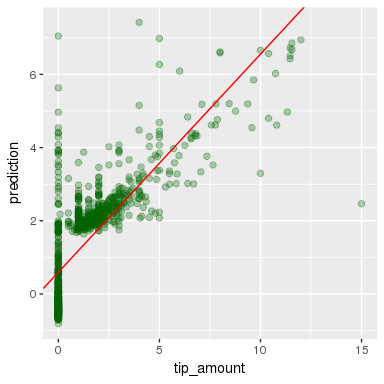

```r
# Sample predictions for plotting
predictedDFSampled <- predictedDF[base::sample(1:nrow(predictedDF), 1000),]

# Plot actual vs. predicted tip amounts
lm_model <- lm(prediction ~ tip_amount, data = predictedDFSampled)
ggplot(predictedDFSampled, aes(tip_amount, prediction)) + geom_point(col='darkgreen', alpha=0.3, pch=19, cex=2) + geom_abline(aes(slope = summary(lm_model)$coefficients[2,1], intercept = summary(lm_model)$coefficients[1,1]), color = "red")
```

### 2.4.2 Creating Random Forest Model

Create a random forest model using training data, and evaluate on test data-set

```r
# Fit Random Forest regression model
fit <- partitions$training %>% ml_random_forest(response = "tip_amount", features = c("pt_bin", "fare_amount", "pickup_hour", "passenger_count",  "trip_distance", "TrafficTimeBuc"), max.bins = 500L, max.depth = 5L, num.trees = 50L)

# Show summary of fitted Random Forest model
summary(fit)
```

```
##                             Length Class      Mode
## features                     6     -none-     character
## response                     1     -none-     character
## max.bins                     1     -none-     numeric
## max.depth                    1     -none-     numeric
## num.trees                    1     -none-     numeric
## feature.importances          6     -none-     numeric
## trees                       50     -none-     list
## data                         2     spark_jobj environment
## ml.options                   6     ml_options list
## categorical.transformations  0     -none-     environment
## model.parameters             5     -none-     list
## .call                        7     -none-     call
## .model                       2     spark_jobj environment
```

```r
# Predict on test data and keep predictions in Spark context
predictedVals <- sdf_predict(fit, newdata =  partitions$test)
predictedDF <- as.data.frame(predictedVals)

# Evaluate and plot predictions (R-sqr)
Rsqr = cor(predictedDF$tip_amount, predictedDF$prediction)^2; Rsqr;
```

```
## [1] 0.7518744
```

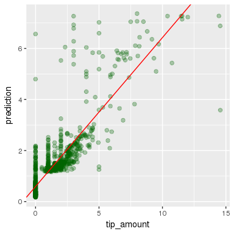

```r
# Sample predictions for plotting
predictedDFSampled <- predictedDF[base::sample(1:nrow(predictedDF), 1000),]

# Plot
lm_model <- lm(prediction ~ tip_amount, data = predictedDFSampled)
ggplot(predictedDFSampled, aes(tip_amount, prediction)) + geom_point(col='darkgreen', alpha=0.3, pch=19, cex=2) + geom_abline(aes(slope = summary(lm_model)$coefficients[2,1], intercept = summary(lm_model)$coefficients[1,1]), color = "red")
```

### 2.4.3 Creating Gradient Boosted Tree Model

Create a gradient boosted tree model using training data, and evaluate on test data-set

```r
# Fit Gradient Boosted Tree regression model
#fit <- partitions$training %>% ml_gradient_boosted_trees(response = "tip_amount", features = c("pt_bin", "fare_amount","pickup_hour","passenger_count","trip_distance","TrafficTimeBuc"), max.bins = 32L, max.depth = 3L, type = "regression")
fit <- partitions$training %>% ml_gradient_boosted_trees(tip_amount ~ pt_bin + pickup_hour + passenger_count + trip_distance + TrafficTimeBuc, max.bins = 32L, max.depth = 3L, type = "regression")


# Show summary of fitted Random Forest model
summary(fit)
```

```
##                             Length Class      Mode
## features                     5     -none-     character
## response                     1     -none-     character
## max.bins                     1     -none-     numeric
## max.depth                    1     -none-     numeric
## trees                       20     -none-     list
## data                         2     spark_jobj environment
## ml.options                   6     ml_options list
## categorical.transformations  0     -none-     environment
## model.parameters             5     -none-     list
## .call                        6     -none-     call
## .model                       2     spark_jobj environment
```

```r
# Predict on test data and keep predictions in Spark context
predictedVals <- sdf_predict(fit, newdata =  partitions$test)
predictedDF <- as.data.frame(predictedVals)

# Evaluate and plot predictions (R-sqr)
Rsqr = cor(predictedDF$tip_amount, predictedDF$prediction)^2; Rsqr;
```

```
## [1] 0.7666482
```

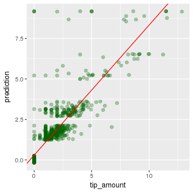

```r
# Sample predictions for plotting
predictedDFSampled <- predictedDF[base::sample(1:nrow(predictedDF), 1000),]

# Plot
lm_model <- lm(prediction ~ tip_amount, data = predictedDFSampled)
ggplot(predictedDFSampled, aes(tip_amount, prediction)) + geom_point(col='darkgreen', alpha=0.3, pch=19, cex=2) + geom_abline(aes(slope = summary(lm_model)$coefficients[2,1], intercept = summary(lm_model)$coefficients[1,1]), color = "red")
```

```r
###########################################
# DISCONNECT SPARK CONNECTION
###########################################
spark_disconnect(sp)
```

# 3 Summary

The examples shown here can be adopted to fit other data exploration and modeling scenarios having different data-types or prediction tasks (e.g. classification)